# CS 1675 Final Project

Consider the calibration curves associated with the cross-validation hold-out sets for the above four models, and a linear model `glmnet`.

```r
rf_test_pred_good <- mod_rf$pred %>% tbl_df() %>%
              filter(mtry == mod_rf$bestTune$mtry) %>%
              select(obs, Fail, rowIndex, Resample)

nnet_test_pred_good <- mod_nnet_b$pred %>% tbl_df() %>%
              filter(size == mod_nnet_b$bestTune$size,
                     decay == mod_nnet_b$bestTune$decay) %>%
              select(obs, Fail, rowIndex, Resample)

xgb_test_pred_good <- mod_xgb$pred %>% tbl_df() %>%
              filter(nrounds == mod_xgb$bestTune$nrounds,
                     max_depth == mod_xgb$bestTune$max_depth,
                     eta %in% mod_xgb$bestTune$eta,
                     gamma %in% mod_xgb$bestTune$gamma,
                     colsample_bytree %in% mod_xgb$bestTune$colsample_bytree,
                     min_child_weight == mod_xgb$bestTune$min_child_weight,
                     subsample == mod_xgb$bestTune$subsample) %>%
              select(obs, Fail, rowIndex, Resample)

mars_test_pred_good <- mod_mars$pred %>% tbl_df() %>%
              filter(nprune == mod_mars$bestTune$nprune,
                     degree == mod_mars$bestTune$degree) %>%
              select(obs, Fail, rowIndex, Resample)

glmnet_3_b_test_pred_good <- mod_glmnet_3_b$pred %>% tbl_df() %>%
              filter(alpha %in% mod_glmnet_3_b$bestTune$alpha,
                     lambda %in% mod_glmnet_3_b$bestTune$lambda) %>%
              select(obs, Fail, rowIndex, Resample)

cal_holdout_preds <- rf_test_pred_good %>% rename(rf = Fail) %>%
  left_join(nnet_test_pred_good %>% rename(nnet = Fail),
            by = c("obs", "rowIndex", "Resample")) %>%
  left_join(xgb_test_pred_good %>% rename(xgb = Fail),
            by = c("obs", "rowIndex", "Resample")) %>%
  left_join(mars_test_pred_good %>% rename(mars = Fail),
            by = c("obs", "rowIndex", "Resample")) %>%
  left_join(glmnet_3_b_test_pred_good %>% rename(glmnet = Fail),
            by = c("obs", "rowIndex", "Resample")) %>%
  select(outcome_2 = obs, rf, nnet, xgb, mars, glmnet)
```

Generate calibration curves.

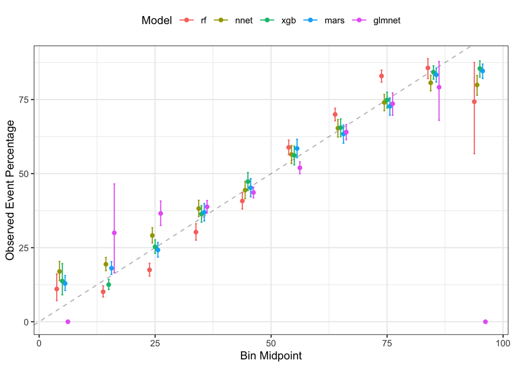

```r
cal_object <- calibration(outcome_2 ~ rf + nnet + xgb + mars + glmnet,
                          data = cal_holdout_preds,
                          cuts = 10)

ggplot(cal_object) + theme_bw() + theme(legend.position = "top")
```

`glmnet` seems to not be so well calibrated.

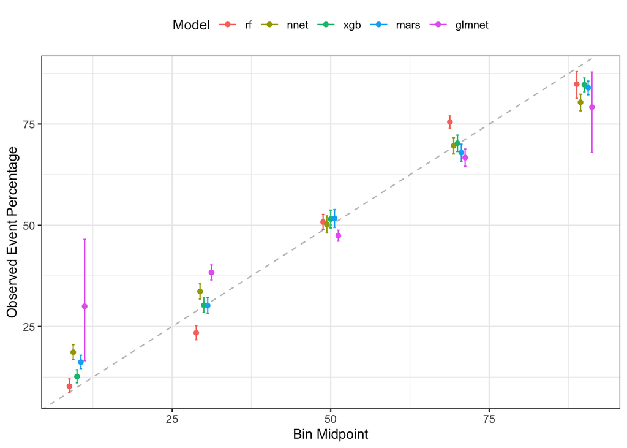

```r
cal_object <- calibration(outcome_2 ~ rf + nnet + xgb + mars + glmnet,
                          data = cal_holdout_preds,
                          cuts = 5)

ggplot(cal_object) + theme_bw() + theme(legend.position = "top")
```

### Accuracy comparison

Based on `Accuracy`, the result for best model appear to be slightly different, although the previously identified four best models are still the same.

```r
calc_accuracy <- function(model) {
  cf <- confusionMatrix.train(model)

  return( (cf$table[1,1] + cf$table[2,2]) / 100 )
}

models <- list(glm = mod_glm, glmnet_2way = mod_glmnet_2_b, glmnet_3way = mod_glmnet_3_b, nnet = mod_nnet_b, rf = mod_rf, xgb = mod_xgb, pls = mod_pls, svm = mod_svm, mars = mod_mars)

accuracy_results <- purrr::map_dbl(models, calc_accuracy)

accuracy_results %>% sort(decreasing = TRUE)
```

```
##          rf         xgb        mars        nnet         svm glmnet_2way
##   0.7335320   0.7223050   0.7218082   0.6949826   0.6850472   0.5915549
##         glm glmnet_3way         pls
##   0.5910581   0.5891704   0.5846995
```

`rf` is the best performing model in terms of `Accuracy`.

### Variable importance rankings

Complex non-linear models can be difficult to interpret. We can consider ranking the relative importance of the input variables in the `step_2_a_df` dataset. Plot variable importance based on `rf` model.

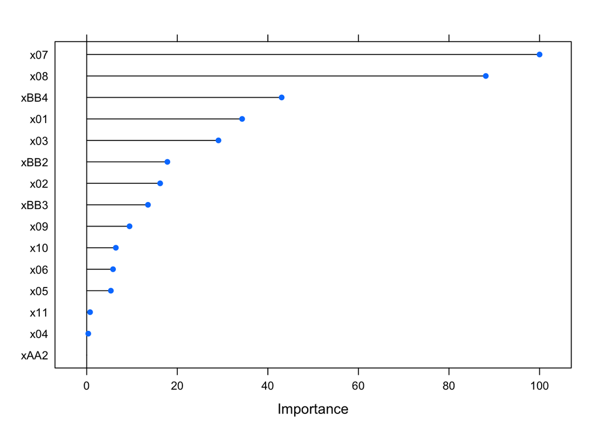

```r
plot(varImp(mod_rf))
```

Plot variable importance based on `xgb` model.

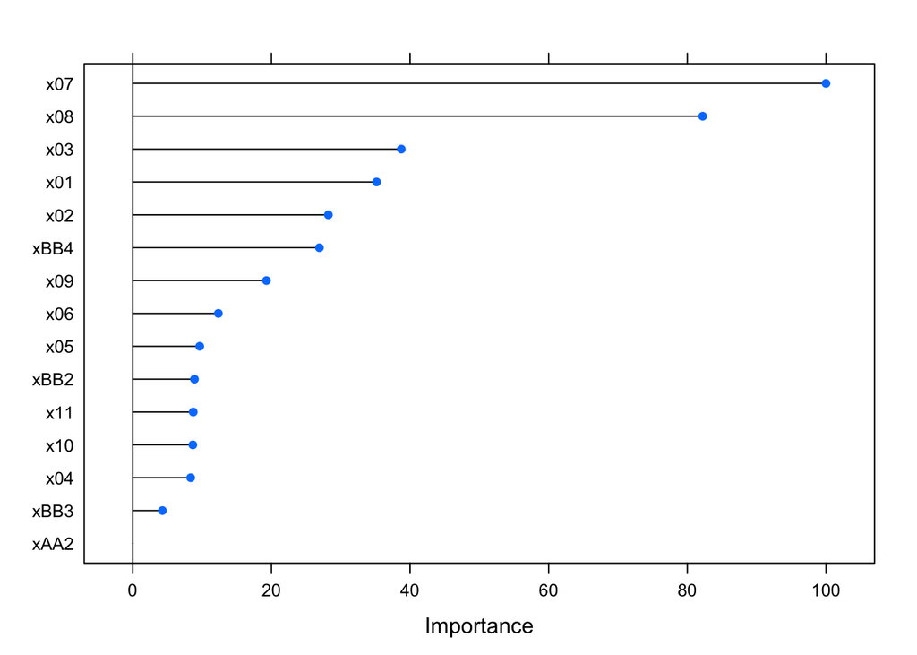

```r
plot(varImp(mod_xgb))
```

`x07` and `x08` seem to be the two most important inputs.

## Saving

```r
# Rename models list item names
names(models) <- c("iv_glm", "iv_glmnet_2way", "iv_glmnet_3way", "iv_nnet", "iv_rf", "iv_xgb", "iv_pls", "iv_svm", "iv_mars")
# Save models list
models %>% readr::write_rds("iv_models.rds")
```